# Personal eBird report

Author

Anne Pier Salverda

Published

March 19, 2025 10:36:30

You can learn a lot about your birding from all of the data that you have contributed to eBird. The analyses in this document use all of your personal eBird data to examine your birding activity and the development of your bird observation skills.

First, some basic statistics:

You have contributed eBird data since **2022**, when you submitted your first checklist on **July 18<sup>th</sup>**. The first bird that you reported that day was a **Gray Catbird**.

## Time spent birding

How much time do you spend eBirding?

The graph below shows the total duration of your checklists, for each month of the year and for each year that you have contributed data to eBird. The current month is indicated by a dot.

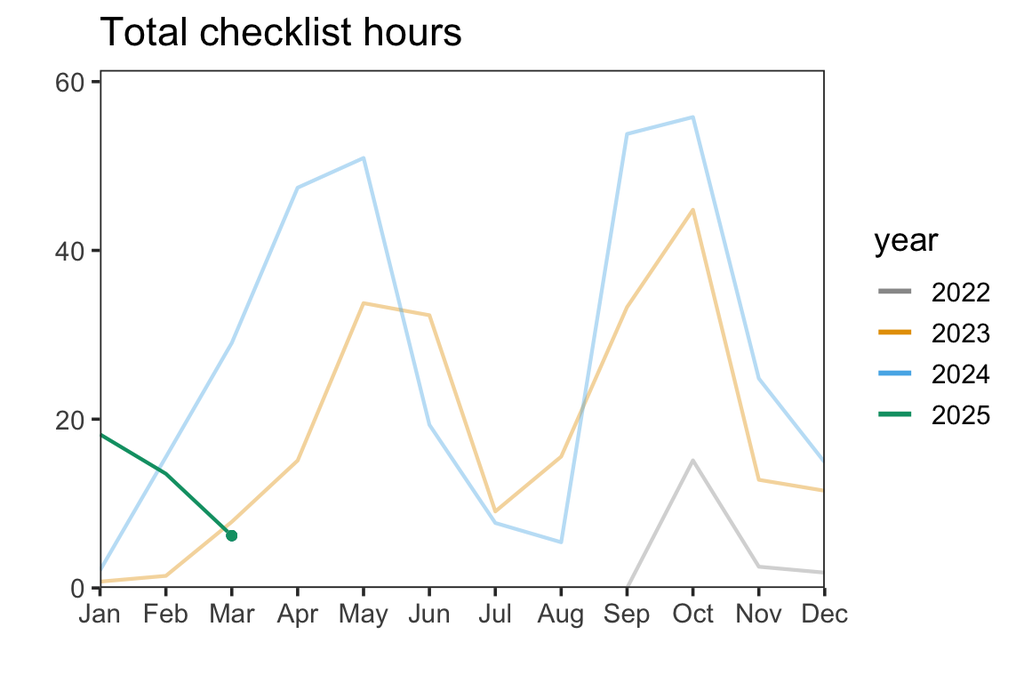

You can see how active you were in each month and throughout each calendar year. For instance, the data suggest that throughout the years, you tend to spend most of your time birding in **the** **Fall**.

The data also suggest that your most active birding year was **2024** when your checklists added up to a total of **327 hours**, or an average of **54 minutes a day.** (You may not want to share this information with your family and friends.)

## Species reported

Many birders keep a list of the species of birds that they have seen in the calendar year. How many species did you report in total, by each day of the year?

As the year progresses, the total number of species that you have reported increases. The graph below shows the total number of species you had reported by day of the year, for each year that you contributed data to eBird. The current month is indicated by a dot.

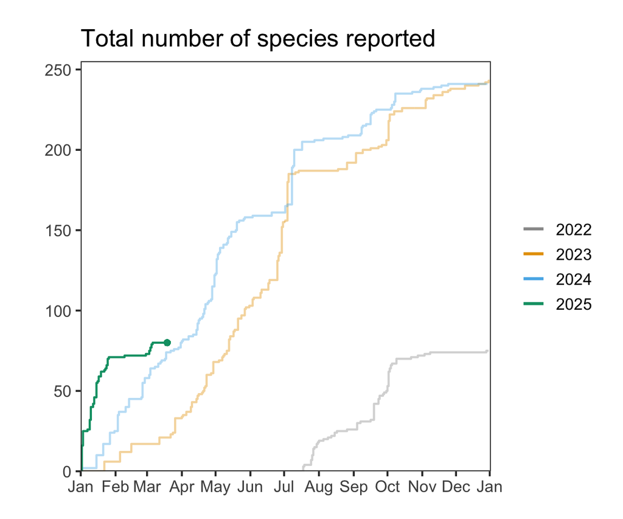

You have seen **80** species so far this year.

Your best species year was **2023** when you saw a total of **243** species.

Note that you can easily glimpse things such as:

- the total number of unique species you reported in each year
- the speed with which you accumulated species throughout the year

Both of these are influenced by a variety of factors, such as your birding skills, the amount of time you spend birding, and the number of species present. For instance, you might see a steep increase during Spring migration, or during that vacation to South-America that you took in the Fall of last year.

## Observation skills

Using eBird data to assess your bird observation skills is not trivial.

#### Species Accumulation Curve

eBird uses an estimate of each user’s bird observation skills called the *Species Accumulation Curve* (Kelling et al. 2015). The total number of species that you report for a checklist naturally increases as a function of the time you spend looking for birds, independently of your observation skills. However, as you become a more experienced birder, your ability to detect birds and your ability to identify what species those birds are improves. This should enable you to report more species of birds per unit of time.

Each checklist that you submit contributes a data point to the Species Accumulation Curve. Each of those data point represents, for a particular checklist, the total number of species you reported and the total amount of time you spent birding. A statistical procedure is used to fit a curve to those data, which captures the rate at which the number of birds you reported increased as a function of the time spent observing birds. The higher this rate, the steeper the curve.

The graph below shows a Species Accumulation Curve for each year that you have contributed data to eBird. As you become a better birder, you should expect the steepness of the curve to increase, indicating that you reported more birds per unit of time. Does the slope of your Species Accumulation Curve increase, year over year? (You may want to discount this year’s curve, since it’s based on partial data for the year.)

[interactive chart not shown]

**Note:** You can move the mouse cursor over the data points in the graph to see some details for the associated checklist, including its location, duration, and the number of species reported Clicking on a data point will open the checklist in eBird.

Do the data indicate that your bird observation skills have improved?

## Top spots

You probably spend more time birding in some locations than others. Some people have a favorite spot that they visit many times a year. The graph below shows the 5 spots in which you spent the most time birding, based on the all the checklists that you have submitted over the years.

| location | total time (hours) |
| --- | --- |
| Sandra L. Frankel Nature Park (Brickyard Trail) | 86.4 |
| Whiting Rd. Nature Preserve | 27.5 |
| High Acres Nature Area | 20.0 |
| Braddock Bay--East Spit | 19.4 |
| Buckland Park | 16.6 |

#### Top spot: Sandra L. Frankel Nature Park (Brickyard Trail)

[interactive chart not shown]

## Top birds

What are the species that you report most frequently? You probably have a hunch, but would you also know what your “top birds” are in each of the four seasons?

The table below shows the percentage of checklists within the season that featured a species, and presents the top 3 species for each season. Even if you do most of your birding in the same area throughout the year, the species that you report most frequently can change quite a bit.

| season | species | percentage of checklists |
| --- | --- | --- |
| spring | 🥇 American Robin | 77 |
|  | 🥈 Northern Cardinal | 68 |
|  | 🥉 Red-winged Blackbird | 65 |
| summer | 🥇 American Goldfinch | 48 |
|  | 🥈 American Robin | 46 |
|  | 🥉 Northern Cardinal | 45 |
| fall | 🥇 Blue Jay | 59 |
|  | 🥈 Red-bellied Woodpecker | 58 |
|  | 🥉 American Crow | 56 |
| winter | 🥇 American Crow | 46 |
|  | 🥈 Black-capped Chickadee | 42 |
|  | 🥉 American Robin | 39 |

## References

Kelling, Steve, Alison Johnston, Wesley M Hochachka, Marshall Iliff, Daniel Fink, Jeff Gerbracht, Carl Lagoze, et al. 2015. “Can Observation Skills of Citizen Scientists Be Estimated Using Species Accumulation Curves?” *PloS One* 10 (10): e0139600.